# Time Series Forecasting - Homework 1

Group 5

## First view of the data

Analyzing data.  
Showing the head and tail of the dataset.

**Head**

|  | Series.1 | Series.2 | Series.3 | Series.4 | Series.5 | Series.6 | Series.7 |
| --- | --- | --- | --- | --- | --- | --- | --- |
| 1 | 0.837 | 1.438 | -1.629 | 0.916 | -0.138 | -0.234 | 9.087 |
| 2 | 0.032 | 1.059 | -1.175 | -0.394 | -0.486 | -0.286 | 8.895 |
| 3 | 0.488 | -0.165 | 0.455 | -2.384 | -0.924 | 0.468 | 9.478 |
| 4 | 0.744 | -1.268 | 2.141 | -3.112 | -1.757 | -1.865 | 7.426 |
| 5 | 0.197 | -1.256 | 2.119 | -4.593 | -0.199 | -0.911 | 7.261 |
| 6 | -0.181 | -0.669 | -0.323 | -6.848 | 0.953 | -1.218 | 6.408 |

**Tail**

|  | Series.1 | Series.2 | Series.3 | Series.4 | Series.5 | Series.6 | Series.7 |
| --- | --- | --- | --- | --- | --- | --- | --- |
| 2995 | NA | NA | NA | NA | NA | 0.021 | 23.348 |
| 2996 | NA | NA | NA | NA | NA | -0.063 | 23.276 |
| 2997 | NA | NA | NA | NA | NA | 0.009 | 23.310 |
| 2998 | NA | NA | NA | NA | NA | -0.707 | 22.600 |
| 2999 | NA | NA | NA | NA | NA | -0.288 | 22.595 |
| 3000 | NA | NA | NA | NA | NA | 0.322 | 23.032 |

Checking the length of each series.

```
[1] "Series 1 has 300 data points."
[1] "Series 2 has 300 data points."
[1] "Series 3 has 300 data points."
[1] "Series 4 has 300 data points."
[1] "Series 5 has 2000 data points."
[1] "Series 6 has 3000 data points."
[1] "Series 7 has 3000 data points."
```

Assignation of series.

```r
series1=data[,1] [1:300]
series2=data[,2] [1:300]
series3=data[,3] [1:300]
series4=data[,4] [1:300]
series5=data[,5] [1:2000]
series6=data[,6]
series7=data[,7]
```

## Series 1

### Graphical exploration (first moment - mean)

In sequence: plot(y), ACF(y) and PACF(y).

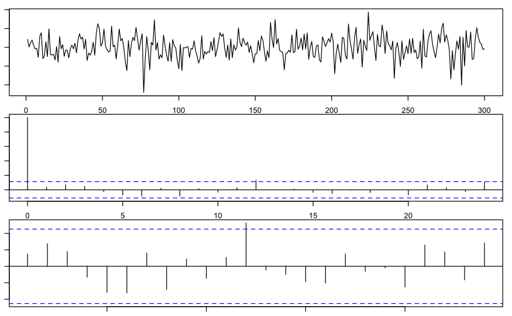

**Observations**:  
- TS (stochastic process) looks stationary in the mean and in the variance.  
- Based on the ACF, data might be correlated. However, we will use the Box-Ljung test to be sure.

### Checking for Normality (graphically)

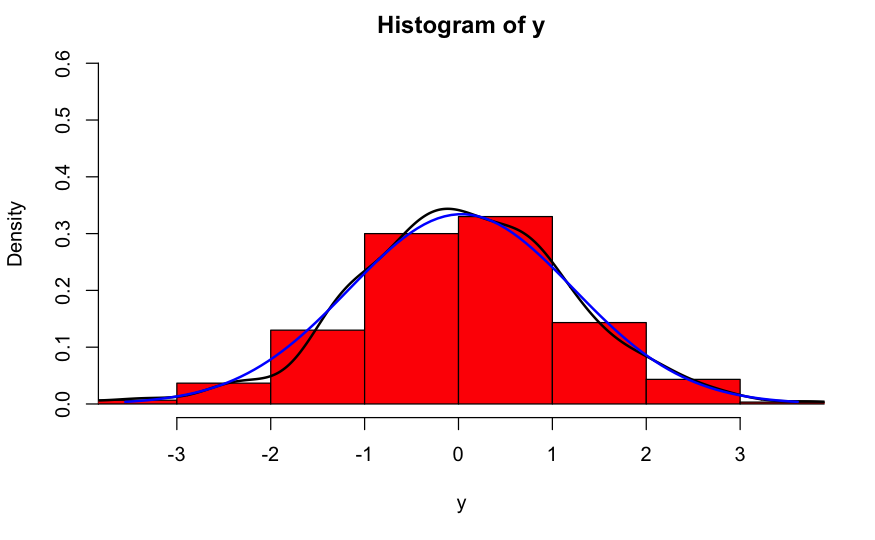

**Observations**:  
- The data may seem normally distributed. However, to be sure we will implement the Shapiro-Wilk test for normality

### Graphical exploration (second moment - variance)

In sequence: plot($y^2$), ACF($y^2$) and PACF($y^2$).

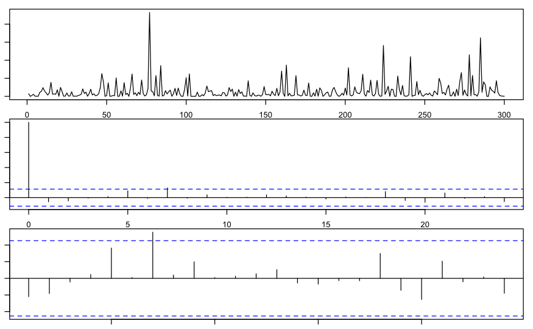

**Observations**:  
- Similar to the first moment.

### Computing basic stats

```r
mean(y) # compute basic statistics
```

```
[1] 0.03205
```

```r
sd(y)
```

```
[1] 1.193712
```

```r
skewness(y)
```

```
[1] -0.2795834
attr(,"method")
[1] "moment"
```

```r
kurtosis(y,method=c("moment"))
```

```
[1] 4.040454
attr(,"method")
[1] "moment"
```

### Checking for CS

```r
# formal unit root test (Augmented Dickey Fuller test). Testing for stationarity.
# Ho: the process is not stationary. We need, at least, a unit root
# H1: the process is stationary. We have to check different models (lags)
ndiffs(y, alpha=0.05, test=c("adf")) # number of regular differences?
```

```
[1] 0
```

**Observations**:  
- TS requires no transformation to become stationary. It is already stationary.

### Checking for Normality

```r
# formal normality test
# Ho: the data is normally distributed
# H1: the data is not normally distributed
shapiro.test(y)
```

```
    Shapiro-Wilk normality test

data:  y
W = 0.98868, p-value = 0.01941
```

**Observations**:  
- We reject $H_0$ since $P_{value} < 0.05$, $\therefore$ the TS is not normally distributed.

### Checking for correlation

```r
# formal test for white noise (zero autocorrelations)
# Ho: uncorrelated data
# H1: correlated data
Box.test (y, lag = 20, type="Ljung")  # Null: ro1=.=ro20=0
```

```
    Box-Ljung test

data:  y
X-squared = 18.804, df = 20, p-value = 0.5346
```

**Observations**:  
- We accept $H_0$ since $P_{value} > 0.05$, $\therefore$ the TS is not correlated in the mean.  
- No linear model can be used since there is no linear relationship between the present and the past.

### Checking for correlation in the second moment

```r
# formal test for white noise (zero autocorrelations)
# Ho: uncorrelated data
# H1: correlated data
Box.test(y^2,lag=20, type="Ljung")    # Null: ro1=.=ro20=0
```

```
    Box-Ljung test

data:  y^2
X-squared = 14.168, df = 20, p-value = 0.8219
```

**Observations**:  
- We accept $H_0$ since $P_{value} > 0.05$, $\therefore$ the TS is not correlated in the variance.  
- No quadratic model can be found.

## Series 2

### Graphical exploration (first moment - mean)

In sequence: plot(y), ACF(y) and PACF(y).

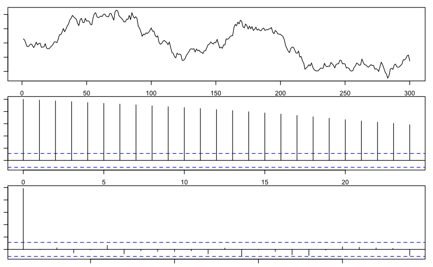

**Observations**:  
- TS (stochastic process) looks no stationary in the mean nor in the variance  
- A downward trend can be observed  
- Based on the ACF, data seems correlated

### Checking for Normality (graphically)

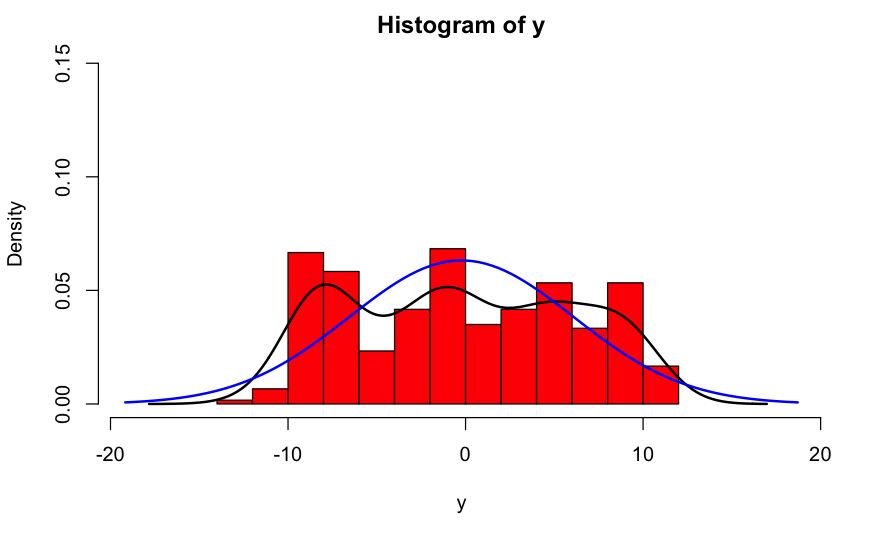

**Observations**:  
- The TS does not appear normally distributed. Data is spread.

### Graphical exploration (second moment - variance)

In sequence: plot($y^2$), ACF($y^2$) and PACF($y^2$).

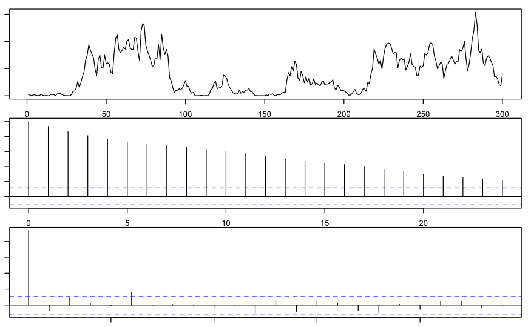

**Observations**:  
- Based on the ACF of the second moment (variance), there seems to be correlation

### Computing basic stats

```r
mean(y) # compute basic statistics
```

```
[1] -0.22853
```

```r
sd(y)
```

```
[1] 6.31268
```

```r
skewness(y)
```

```
[1] 0.04883792
attr(,"method")
[1] "moment"
```

```r
kurtosis(y,method=c("moment"))
```

```
[1] 1.765163
attr(,"method")
[1] "moment"
```

### Checking for CS

```r
# formal unit root test (Augmented Dickey Fuller test). Testing for stationarity.
# Ho: the process is not stationary. We need, at least, a unit root
# H1: the process is stationary. We have to check different models (lags)
ndiffs(y, alpha=0.05, test=c("adf")) # number of regular differences?
```

```
[1] 1
```

**Observations**:  
- TS requires transformation to become stationary  
- To make it stationary we need to apply the first difference

### Checking for Normality

```r
# formal normality test
# Ho: the data is normally distributed
# H1: the data is not normally distributed
shapiro.test(y)
```

```
    Shapiro-Wilk normality test

data:  y
W = 0.94921, p-value = 1.133e-08
```

**Observations**:  
- We reject $H_0$ since $P_{value} < 0.05$, $\therefore$ the TS is not normally distributed

### Checking for correlation

```r
# formal test for white noise (zero autocorrelations)
# Ho: uncorrelated data
# H1: correlated data
Box.test (y, lag = 20, type="Ljung")  # Null: ro1=.=ro20=0
```

```
    Box-Ljung test

data:  y
X-squared = 4509.5, df = 20, p-value < 2.2e-16
```

**Observations**:  
- We reject $H_0$ since $P_{value} < 0.05$, $\therefore$ the TS is correlated in the mean

### Checking for correlation in the second moment

```r
# formal test for white noise (zero autocorrelations)
# Ho: uncorrelated data
# H1: correlated data
Box.test(y^2,lag=20, type="Ljung")    # Null: ro1=.=ro20=0
```

```
    Box-Ljung test

data:  y^2
X-squared = 2317.4, df = 20, p-value < 2.2e-16
```

**Observations**:  
- We reject $H_0$ since $P_{value} < 0.05$, $\therefore$ the TS is correlated in the variance

### Transformed data

Applying the formula without defining the difference value (default = 1)

In sequence: plot(z), ACF(z) and PACF(z).

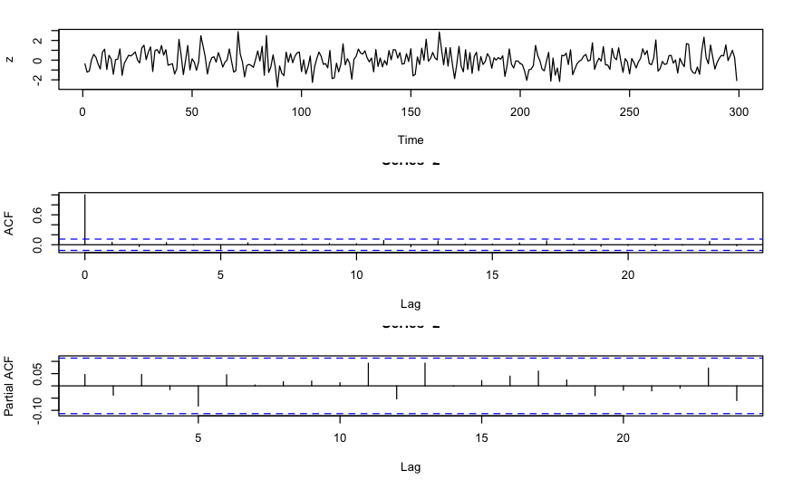

**Observations**:  
- After transformation, TS looks stationary

Checking for CS

```r
ndiffs(z, alpha=0.05, test=c("adf"))
```

```
[1] 0
```

**Observations**:  
- Confirmation that no transformation is needed - data is stationary

checking for normality (graphically)

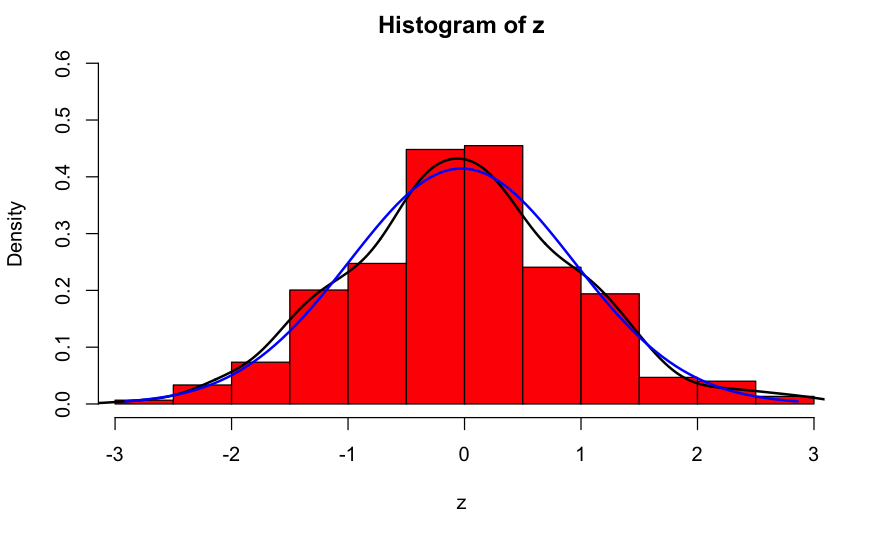

**Observations**:  
- The data may seem normally distributed. However, to be sure we will implement the Shapiro-Wilk test for normality

Checking for normality (formal)

```r
shapiro.test(z)
```

```
    Shapiro-Wilk normality test

data:  z
W = 0.99619, p-value = 0.69
```

**Observations**:  
- We accept $H_0$ since $P_{value} > 0.05$, $\therefore$ the TS is normally distributed

Checking for correlation (first moment - mean)

```r
Box.test (z, lag = 20, type="Ljung")
```

```
    Box-Ljung test

data:  z
X-squared = 12.452, df = 20, p-value = 0.8996
```

**Observations**:  
- We accept $H_0$ since $P_{value} > 0.05$  
- TS is uncorrelated (not correlated) in the mean  
- TS is WN  
- TS is GWN since data is normally distributed  
- TS is SWN since GWN implies SWN

Checking for correlation (second moment - variance)

```r
Box.test (z^2, lag = 20, type="Ljung")
```

```
    Box-Ljung test

data:  z^2
X-squared = 9.7899, df = 20, p-value = 0.9718
```

**Observations**:  
- We accept $H_0$ since $P_{value} > 0.05$ - TS is uncorrelated (not correlated) in the variance

## Series 3

### Graphical exploration (first moment - mean)

In sequence: plot(y), ACF(y) and PACF(y).

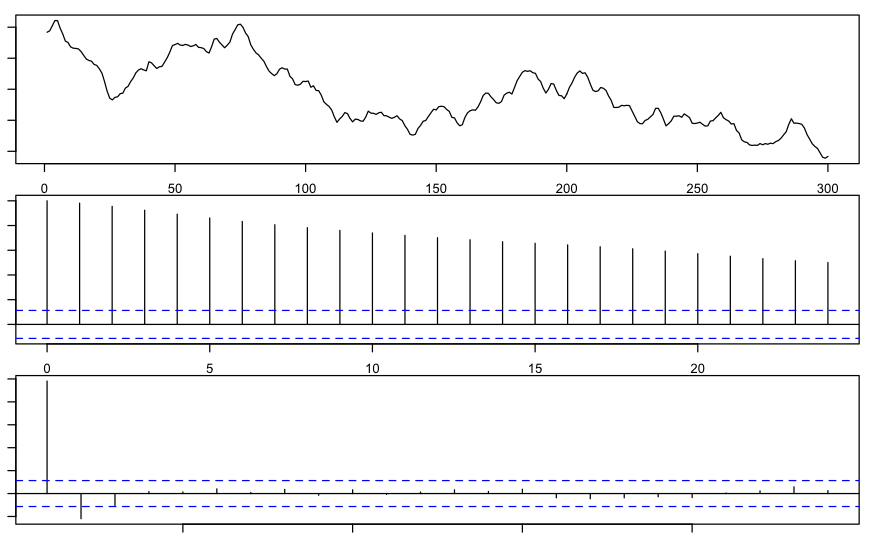

**Observations**:  
- TS shows downward trend - TS looks no stationary - TS seems to have correlated data

### Checking for Normality (graphically)

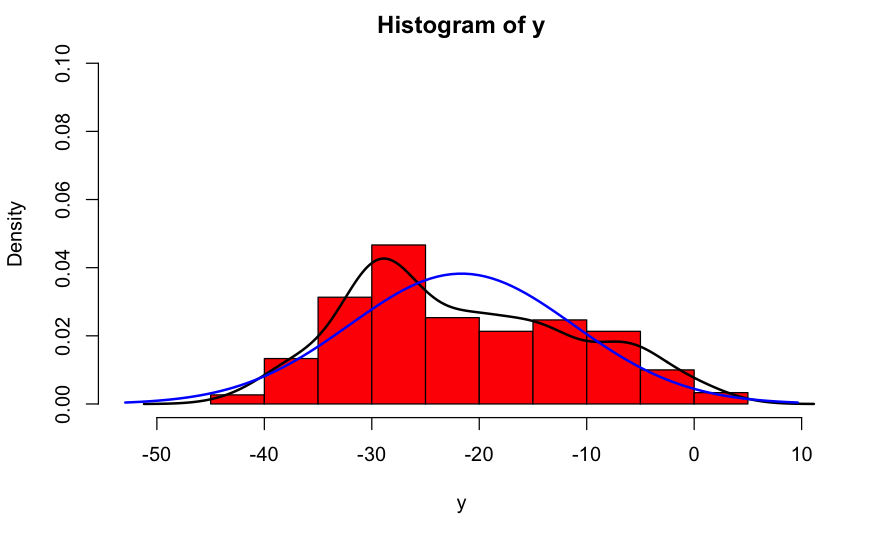

**Observations**:  
- TS seems not normally distributed

### Graphical exploration (second moment - variance)

In sequence: plot($y^2$), ACF($y^2$) and PACF($y^2$).

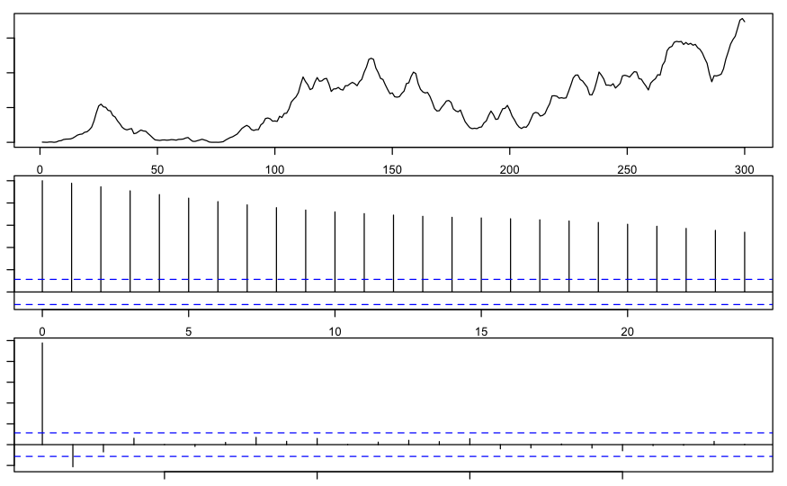

**Observations**:  
- TS (second moment - variance) shows an upward trend and correlated data

### Computing basic stats

```r
mean(y) # compute basic statistics
```

```
[1] -21.65212
```

```r
sd(y)
```

```
[1] 10.42905
```

```r
skewness(y)
```

```
[1] 0.3495993
attr(,"method")
[1] "moment"
```

```r
kurtosis(y,method=c("moment"))
```

```
[1] 2.197106
attr(,"method")
[1] "moment"
```

### Checking for CS

```r
# formal unit root test (Augmented Dickey Fuller test). Testing for stationarity.
# Ho: the process is not stationary. We need, at least, a unit root
# H1: the process is stationary. We have to check different models (lags)
ndiffs(y, alpha=0.05, test=c("adf")) # number of regular differences?
```

```
[1] 1
```

**Observations**:  
- TS requires transformation to become stationary  
- To make it stationary we need to apply the first difference

### Checking for Normality

```r
# formal normality test
# Ho: the data is normally distributed
# H1: the data is not normally distributed
shapiro.test(y)
```

```
    Shapiro-Wilk normality test

data:  y
W = 0.9645, p-value = 1.019e-06
```

**Observations**:  
- We reject $H_0$ since $P_{value} < 0.05$, $\therefore$ the TS is not normally distributed

### Checking for correlation

```r
# formal test for white noise (zero autocorrelations)
# Ho: uncorrelated data
# H1: correlated data
Box.test (y, lag = 20, type="Ljung")  # Null: ro1=.=ro20=0
```

```
    Box-Ljung test

data:  y
X-squared = 3598.9, df = 20, p-value < 2.2e-16
```

**Observations**:  
- We reject $H_0$ since $P_{value} < 0.05$, $\therefore$ the TS has correlated data in the mean - TS is not WN, GWN or SWN - Linear model possible

### Checking for correlation in the second moment

```r
# formal test for white noise (zero autocorrelations)
# Ho: uncorrelated data
# H1: correlated data
Box.test(y^2,lag=20, type="Ljung")    # Null: ro1=.=ro20=0
```

```
    Box-Ljung test

data:  y^2
X-squared = 3552, df = 20, p-value < 2.2e-16
```

**Observations**:  
- We reject $H_0$ since $P_{value} < 0.05$, $\therefore$ the TS has correlated data in the variance  
- Non-linear model may be possible but not needed

### Transformed data

Applying the formula without defining the difference value (default = 1)

```r
# Just in case we need to take one difference to the original data (as in this case)

z<-diff(y)
#ts.plot(z)
```

Checking graphically and with formal test for stationarity, normality and correlation (in the mean and in the variance)  
In sequence: plot(z), ACF(z) and PACF(z).

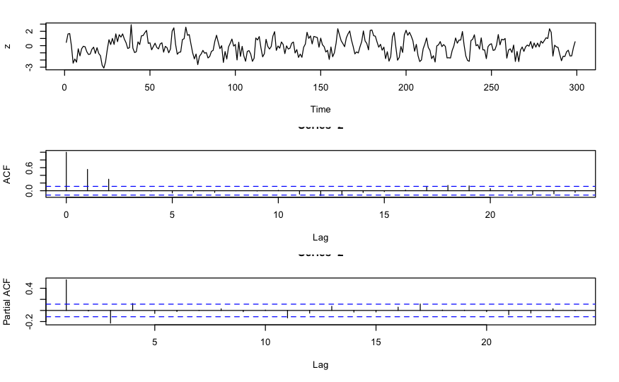

```
[1] 0

    Box-Ljung test

data:  z
X-squared = 148.71, df = 20, p-value < 2.2e-16


    Box-Ljung test

data:  z^2
X-squared = 47.582, df = 20, p-value = 0.0004868
```

```
    Shapiro-Wilk normality test

data:  z
W = 0.99344, p-value = 0.2178
```

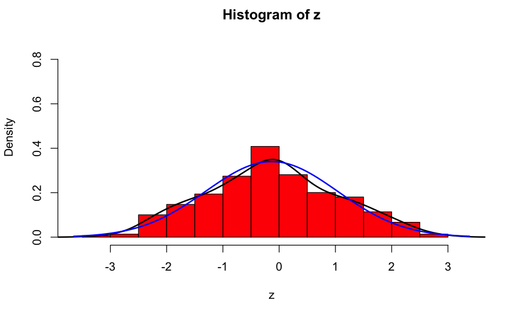

**Observations**:  
- TS is stationary (constant mean and variance across time). No more transformations are needed.  
- TS data is normally distributed since we accept $H_0$ given that $P_{value} > 0.05$  
- TS is correlated in the mean or variance since we reject $H_0$ for both given that $P_{value} < 0.05$, $\therefore$ TS is not WN, GWN or SWN  
- Linear model possible. Also, a non-linear one but not needed.

## Series 4

### Graphical exploration (first moment - mean)

In sequence: plot(y), ACF(y) and PACF(y).

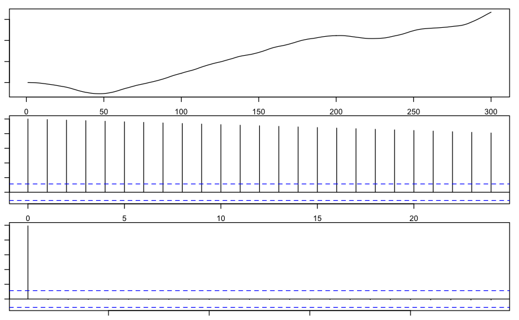

**Observations**:  
- TS shows upward trend - TS shows correlation in data

### Checking for Normality (graphically)

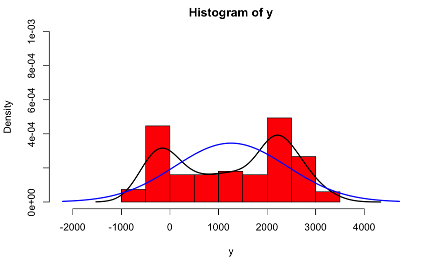

**Observations**:  
- TS not normally distributed

### Graphical exploration (second moment - variance)

In sequence: plot($y^2$), ACF($y^2$) and PACF($y^2$).

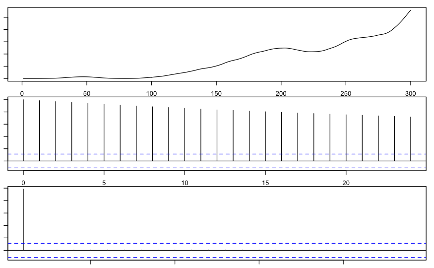

**Observations**:  
- TS shows an upward trend and correlated data in the variance

### Computing basic stats

```r
mean(y) # compute basic statistics
```

```
[1] 1256.843
```

```r
sd(y)
```

```
[1] 1154.857
```

```r
skewness(y)
```

```
[1] -0.1488262
attr(,"method")
[1] "moment"
```

```r
kurtosis(y,method=c("moment"))
```

```
[1] 1.559977
attr(,"method")
[1] "moment"
```

### Checking for CS

```r
# formal unit root test (Augmented Dickey Fuller test). Testing for stationarity.
# Ho: the process is not stationary. We need, at least, a unit root
# H1: the process is stationary. We have to check different models (lags)
ndiffs(y, alpha=0.05, test=c("adf")) # number of regular differences?
```

```
[1] 2
```

**Observations**:  
- TS requires two differences to become stationary

### Checking for Normality

```r
# formal normality test
# Ho: the data is normally distributed
# H1: the data is not normally distributed
shapiro.test(y)
```

```
    Shapiro-Wilk normality test

data:  y
W = 0.91161, p-value = 2.779e-12
```

**Observations**:  
- We reject $H_0$ since $P_{value} < 0.05$, $\therefore$ the TS is not normally distributed

### Checking for correlation

```r
# formal test for white noise (zero autocorrelations)
# Ho: uncorrelated data
# H1: correlated data
Box.test (y, lag = 20, type="Ljung")  # Null: ro1=.=ro20=0
```

```
    Box-Ljung test

data:  y
X-squared = 5290.9, df = 20, p-value < 2.2e-16
```

**Observations**:  
- We reject $H_0$ since $P_{value} < 0.05$, $\therefore$ the TS has correlated data in the mean - TS is not WN or GWN

### Checking for correlation in the second moment

```r
# formal test for white noise (zero autocorrelations)
# Ho: uncorrelated data
# H1: correlated data
Box.test(y^2,lag=20, type="Ljung")    # Null: ro1=.=ro20=0
```

```
    Box-Ljung test

data:  y^2
X-squared = 4641.8, df = 20, p-value < 2.2e-16
```

**Observations**:  
- We reject $H_0$ since $P_{value} < 0.05$, $\therefore$ the TS has correlated data in the variance - TS is not SWN for the first and second moments. We do not know if SWN for others but we do not care.

### Transformed data

Applying the formula defining the difference value = 2 and checking graphically for stationarity.

In sequence: plot(z), ACF(z) and PACF(z).

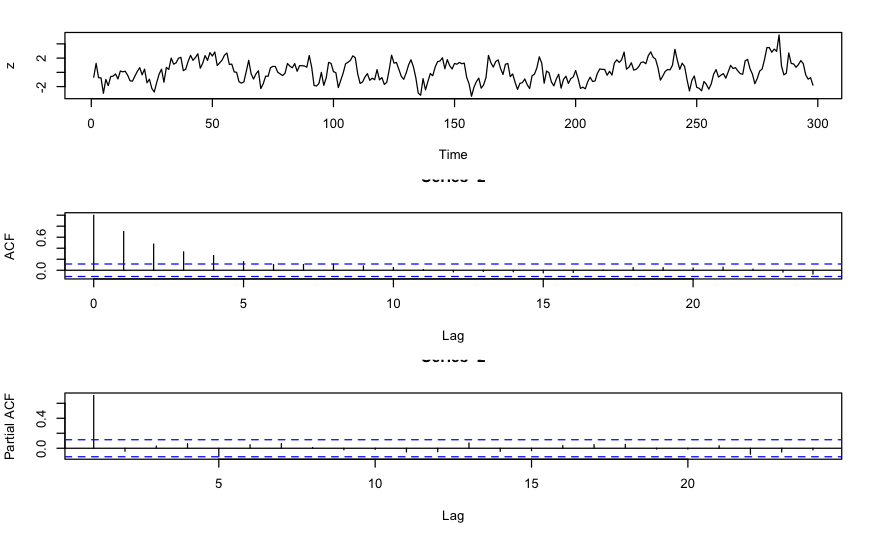

**Observations**:  
- TS looks stationary - TS shows correlated data

Checking for CS

```r
ndiffs(z, alpha=0.05, test=c("adf"))
```

```
[1] 0
```

**Observations**:  
- Confirmation that no transformation is needed - data is stationary

checking for normality (graphically)

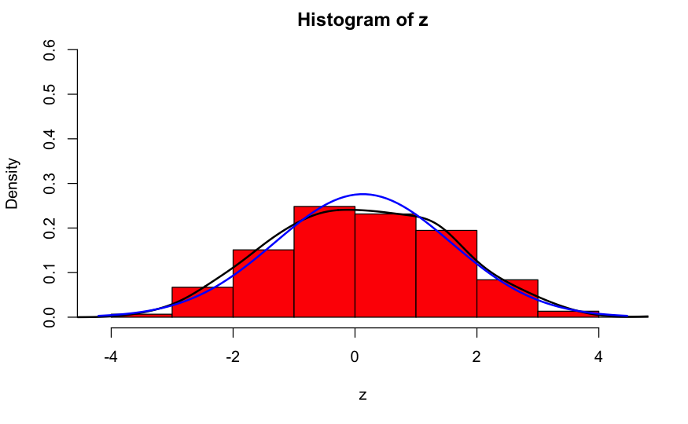

**Observations**:  
- The data may seem normally distributed. However, to be sure we will implement the Shapiro-Wilk test for normality

Checking for normality (formal)

```r
shapiro.test(z)
```

```
    Shapiro-Wilk normality test

data:  z
W = 0.99438, p-value = 0.3416
```

**Observations**:  
- We accept $H_0$ since $P_{value} > 0.05$, $\therefore$ the TS is normally distributed

Checking for correlation (first moment - mean)

```r
Box.test (z, lag = 20, type="Ljung")
```

```
    Box-Ljung test

data:  z
X-squared = 297.76, df = 20, p-value < 2.2e-16
```

**Observations**:  
- We reject $H_0$ since $P_{value} < 0.05$  
- TS is correlated in the mean  
- TS is not WN, GWN or SWN

Checking for correlation (second moment - variance)

```r
Box.test (z^2, lag = 20, type="Ljung")
```

```
    Box-Ljung test

data:  z^2
X-squared = 72.7, df = 20, p-value = 6.562e-08
```

**Observations**:  
- We reject $H_0$ since $P_{value} < 0.05$  
- TS is correlated in the variance

## Series 5

### Graphical exploration (first moment - mean)

In sequence: plot(y), ACF(y) and PACF(y).

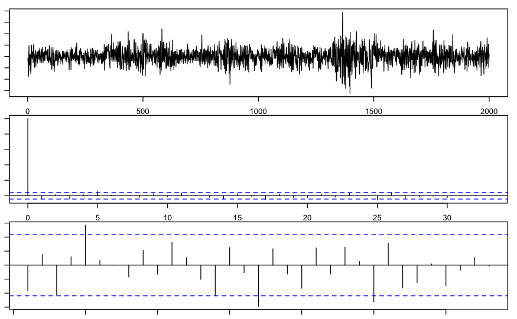

**Observations**:  
- TS seems stationary and could be correlated

### Checking for Normality (graphically)

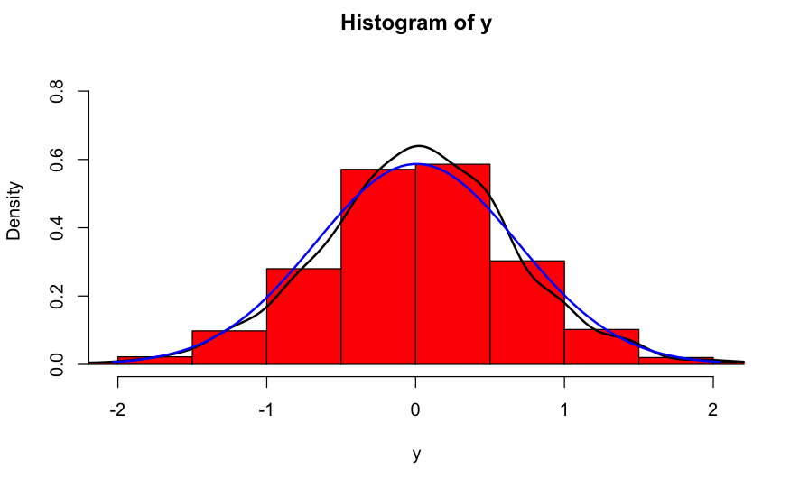

**Observations**:  
- The data may seems normally distributed. However, to be sure we will implement the Shapiro-Wilk test for normality

### Graphical exploration (second moment - variance)

In sequence: plot($y^2$), ACF($y^2$) and PACF($y^2$).

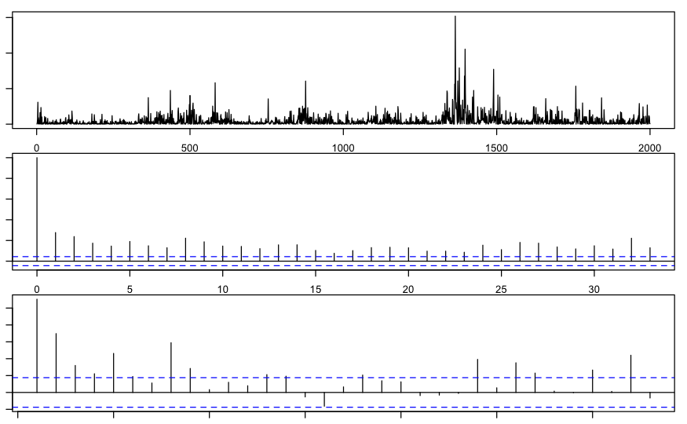

**Observations**:  
- TS (second moment) appears correlated

### Computing basic stats

```r
mean(y) # compute basic statistics
```

```
[1] 0.0071755
```

```r
sd(y)
```

```
[1] 0.6797896
```

```r
skewness(y)
```

```
[1] -0.08744834
attr(,"method")
[1] "moment"
```

```r
kurtosis(y,method=c("moment"))
```

```
[1] 4.36924
attr(,"method")
[1] "moment"
```

### Checking for CS

```r
# formal unit root test (Augmented Dickey Fuller test). Testing for stationarity.
# Ho: the process is not stationary. We need, at least, a unit root
# H1: the process is stationary. We have to check different models (lags)
ndiffs(y, alpha=0.05, test=c("adf")) # number of regular differences?
```

```
[1] 0
```

**Observations**:  
- Confirmation of CS

### Checking for Normality

```r
# formal normality test
# Ho: the data is normally distributed
# H1: the data is not normally distributed
shapiro.test(y)
```

```
    Shapiro-Wilk normality test

data:  y
W = 0.99047, p-value = 3.456e-10
```

**Observations**:  
- We reject $H_0$ since $P_{value} < 0.05$, $\therefore$ the TS is not normally distributed

### Checking for correlation

```r
# formal test for white noise (zero autocorrelations)
# Ho: uncorrelated data
# H1: correlated data
Box.test (y, lag = 20, type="Ljung")  # Null: ro1=.=ro20=0
```

```
    Box-Ljung test

data:  y
X-squared = 33.151, df = 20, p-value = 0.03248
```

**Observations**:  
- We reject $H_0$ since $P_{value} < 0.05$, $\therefore$ the TS has correlated data in the mean  
- No WN, GWN or SWN

### Checking for correlation in the second moment

```r
# formal test for white noise (zero autocorrelations)
# Ho: uncorrelated data
# H1: correlated data
Box.test(y^2,lag=20, type="Ljung")    # Null: ro1=.=ro20=0
```

```
    Box-Ljung test

data:  y^2
X-squared = 1061.5, df = 20, p-value < 2.2e-16
```

**Observations**:  
- We reject $H_0$ since $P_{value} < 0.05$, $\therefore$ the TS has correlated data in the variance

## Series 6

### Graphical exploration (first moment - mean)

In sequence: plot(y), ACF(y) and PACF(y).

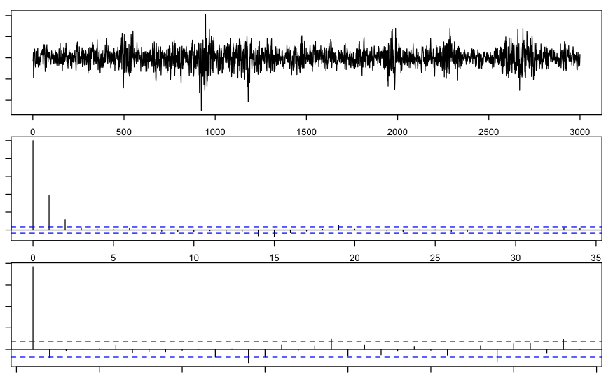

**Observations**:  
- TS seems stationary and correlated

### Checking for Normality (graphically)

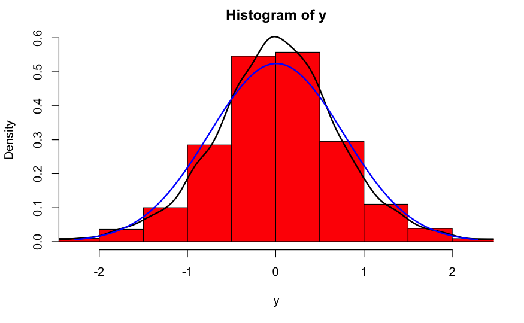

**Observations**:  
- The data may seem normally distributed. However, to be sure we will implement the Shapiro-Wilk test for normality

### Graphical exploration (second moment - variance)

In sequence: plot($y^2$), ACF($y^2$) and PACF($y^2$).

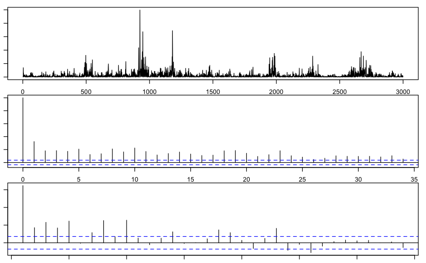

**Observations**:  
- TS seems stationary and correlated

### Computing basic stats

```r
mean(y) # compute basic statistics
```

```
[1] 0.007541
```

```r
sd(y)
```

```
[1] 0.7605913
```

```r
skewness(y)
```

```
[1] -0.2023789
attr(,"method")
[1] "moment"
```

```r
kurtosis(y,method=c("moment"))
```

```
[1] 5.113352
attr(,"method")
[1] "moment"
```

### Checking for CS

```r
# formal unit root test (Augmented Dickey Fuller test). Testing for stationarity.
# Ho: the process is not stationary. We need, at least, a unit root
# H1: the process is stationary. We have to check different models (lags)
ndiffs(y, alpha=0.05, test=c("adf")) # number of regular differences?
```

```
[1] 0
```

**Observations**:  
- TS is stationary

### Checking for Normality

```r
# formal normality test
# Ho: the data is normally distributed
# H1: the data is not normally distributed
shapiro.test(y)
```

```
    Shapiro-Wilk normality test

data:  y
W = 0.98338, p-value < 2.2e-16
```

**Observations**:  
- We reject $H_0$ since $P_{value} < 0.05$, $\therefore$ the TS is not normally distributed

### Checking for correlation

```r
# formal test for white noise (zero autocorrelations)
# Ho: uncorrelated data
# H1: correlated data
Box.test (y, lag = 20, type="Ljung")  # Null: ro1=.=ro20=0
```

```
    Box-Ljung test

data:  y
X-squared = 537.69, df = 20, p-value < 2.2e-16
```

**Observations**:  
- We reject $H_0$ since $P_{value} < 0.05$, $\therefore$ the TS has correlated data in the mean  
- TS is not WN, GWN or SWN  
- Linear model possible. Also, non-linear model possible but not needed.

### Checking for correlation in the second moment

```r
# formal test for white noise (zero autocorrelations)
# Ho: uncorrelated data
# H1: correlated data
Box.test(y^2,lag=20, type="Ljung")    # Null: ro1=.=ro20=0
```

```
    Box-Ljung test

data:  y^2
X-squared = 1856.6, df = 20, p-value < 2.2e-16
```

**Observations**:  
- We reject $H_0$ since $P_{value} < 0.05$, $\therefore$ the TS has correlated data in the variance

## Series 7

### Graphical exploration (first moment - mean)

In sequence: plot(y), ACF(y) and PACF(y).

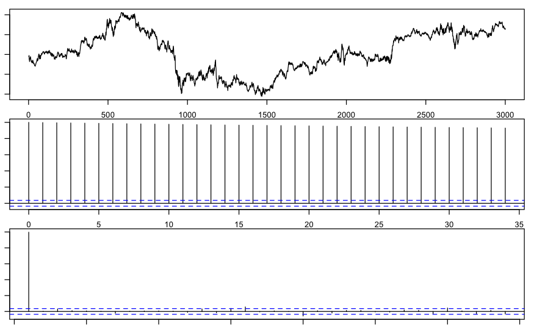

**Observations**:  
- TS seems not stationary since mean is not constant across time  
- TS the variance seems to be different across time  
- TS has correlated data

### Checking for Normality (graphically)

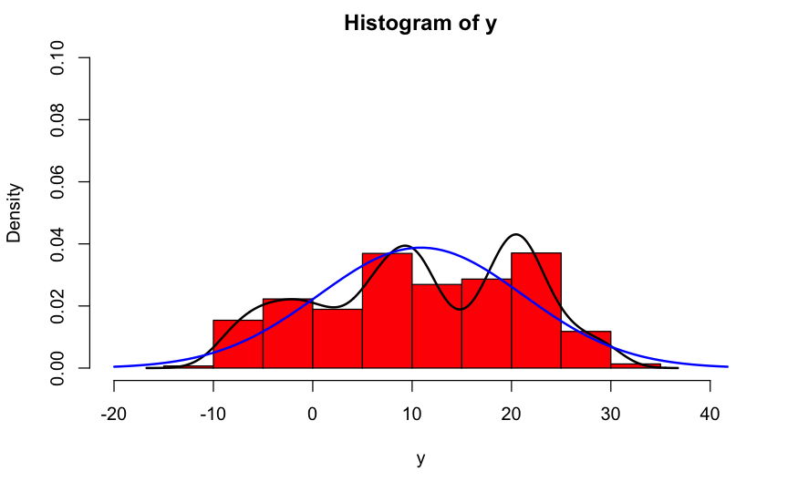

**Observations**:  
- TS seems not normally distributed

### Graphical exploration (second moment - variance)

In sequence: plot($y^2$), ACF($y^2$) and PACF($y^2$).

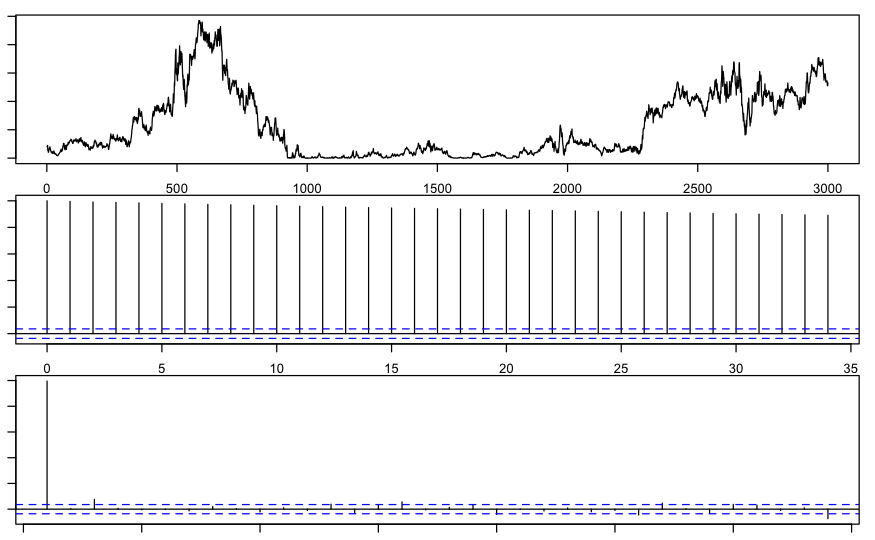

**Observations**:  
- TS does not seem stationary in the variance - TS seems correlated

### Computing basic stats

```r
mean(y) # compute basic statistics
```

```
[1] 10.88196
```

```r
sd(y)
```

```
[1] 10.28588
```

```r
skewness(y)
```

```
[1] -0.1702387
attr(,"method")
[1] "moment"
```

```r
kurtosis(y,method=c("moment"))
```

```
[1] 2.00975
attr(,"method")
[1] "moment"
```

### Checking for CS

```r
# formal unit root test (Augmented Dickey Fuller test). Testing for stationarity.
# Ho: the process is not stationary. We need, at least, a unit root
# H1: the process is stationary. We have to check different models (lags)
ndiffs(y, alpha=0.05, test=c("adf")) # number of regular differences?
```

```
[1] 1
```

**Observations**:  
- TS needs transformation (difference operator = 1). Meaning that we need to take the first difference in order to make it stationary.

### Checking for Normality

```r
# formal normality test
# Ho: the data is normally distributed
# H1: the data is not normally distributed
shapiro.test(y)
```

```
    Shapiro-Wilk normality test

data:  y
W = 0.96711, p-value < 2.2e-16
```

**Observations**:  
- We reject $H_0$ since $P_{value} < 0.05$, $\therefore$ the TS is not normally distributed

### Checking for correlation

```r
# formal test for white noise (zero autocorrelations)
# Ho: uncorrelated data
# H1: correlated data
Box.test (y, lag = 20, type="Ljung")  # Null: ro1=.=ro20=0
```

```
    Box-Ljung test

data:  y
X-squared = 57372, df = 20, p-value < 2.2e-16
```

**Observations**:  
- We reject $H_0$ since $P_{value} < 0.05$, $\therefore$ the TS has correlated data in the mean - TS is not WN, GWN or SWN  
- Linear model possible

### Checking for correlation in the second moment

```r
# formal test for white noise (zero autocorrelations)
# Ho: uncorrelated data
# H1: correlated data
Box.test(y^2,lag=20, type="Ljung")    # Null: ro1=.=ro20=0
```

```
    Box-Ljung test

data:  y^2
X-squared = 55788, df = 20, p-value < 2.2e-16
```

**Observations**:  
- We reject $H_0$ since $P_{value} < 0.05$, $\therefore$ the TS has correlated data in the variance - Non-linear model possible but not needed.

### Transformed data

Applying the formula without defining the difference value (default = 1) and checking graphically for stationarity.

In sequence: plot(z), ACF(z) and PACF(z).

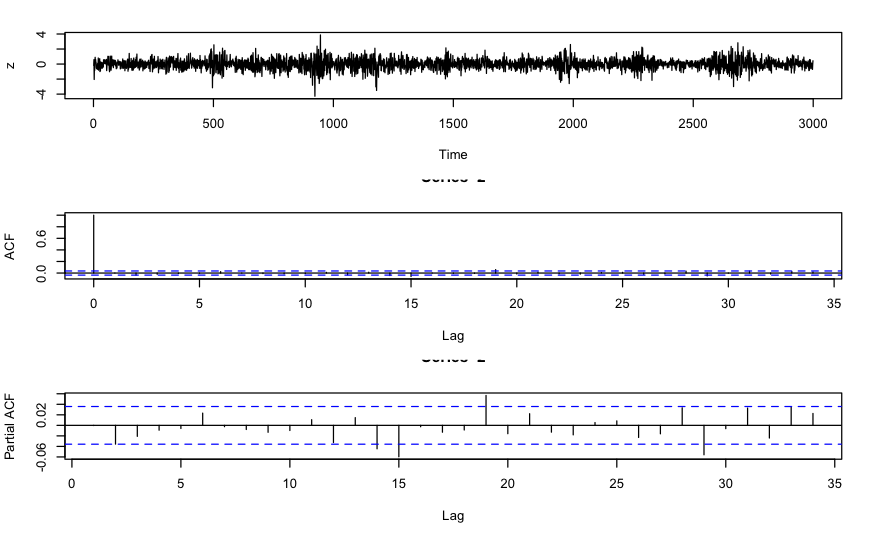

**Observations**:  
- TS looks stationary

Checking for CS

```r
ndiffs(z, alpha=0.05, test=c("adf"))
```

```
[1] 0
```

**Observations**:  
- Confirmation that no transformation is needed - data is stationary

checking for normality (graphically)

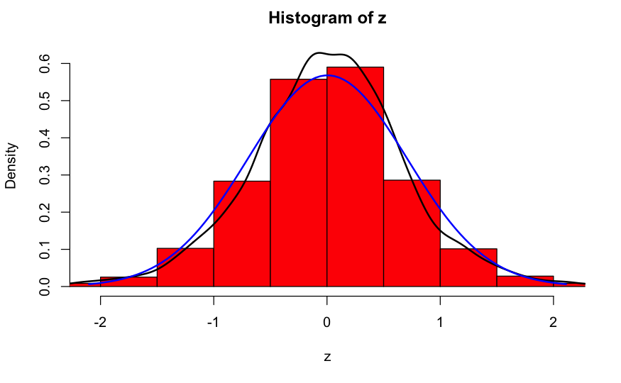

**Observations**:  
- The data may seem normally distributed. However, to be sure we will implement the Shapiro-Wilk test for normality

Checking for normality (formal)

```r
shapiro.test(z)
```

```
    Shapiro-Wilk normality test

data:  z
W = 0.98584, p-value < 2.2e-16
```

**Observations**:  
- We reject $H_0$ since $P_{value} < 0.05$, $\therefore$ the TS is not normally distributed

Checking for correlation (first moment - mean)

```r
Box.test (z, lag = 20, type="Ljung")
```

```
    Box-Ljung test

data:  z
X-squared = 40.012, df = 20, p-value = 0.004978
```

**Observations**:  
- We reject $H_0$ since $P_{value} < 0.05$ - TS is correlated in the mean  
- TS is not WN, GWN or SWN

Checking for correlation (second moment - variance)

```r
Box.test (z^2, lag = 20, type="Ljung")
```

```
    Box-Ljung test

data:  z^2
X-squared = 1632.1, df = 20, p-value < 2.2e-16
```

**Observations**:  
- We reject $H_0$ since $P_{value} < 0.05$ - TS is correlated in the variance